# Risk Factor Analysis

## Outcome Variable

**Outcome Variable:** pers_wast

## Predictor Variables

**Intervention Variable:** fhtcm

**Adjustment Set:**

unadjusted

## Stratifying Variables

The analysis was stratified on these variable(s):

- agecat
- studyid
- country

## Data Summary

| agecat | studyid | country | fhtcm | pers_wast | n_cell | n |
| --- | --- | --- | --- | --- | --- | --- |
| 0-24 months | ki1000304b-SAS-CompFeed | INDIA | >=167 cm | 0 | 358 | 824 |
| 0-24 months | ki1000304b-SAS-CompFeed | INDIA | >=167 cm | 1 | 27 | 824 |
| 0-24 months | ki1000304b-SAS-CompFeed | INDIA | <162 cm | 0 | 179 | 824 |
| 0-24 months | ki1000304b-SAS-CompFeed | INDIA | <162 cm | 1 | 15 | 824 |
| 0-24 months | ki1000304b-SAS-CompFeed | INDIA | [162-167) cm | 0 | 222 | 824 |
| 0-24 months | ki1000304b-SAS-CompFeed | INDIA | [162-167) cm | 1 | 23 | 824 |
| 0-24 months | ki1000304b-SAS-FoodSuppl | INDIA | >=167 cm | 0 | 89 | 370 |
| 0-24 months | ki1000304b-SAS-FoodSuppl | INDIA | >=167 cm | 1 | 11 | 370 |
| 0-24 months | ki1000304b-SAS-FoodSuppl | INDIA | <162 cm | 0 | 118 | 370 |
| 0-24 months | ki1000304b-SAS-FoodSuppl | INDIA | <162 cm | 1 | 34 | 370 |
| 0-24 months | ki1000304b-SAS-FoodSuppl | INDIA | [162-167) cm | 0 | 100 | 370 |
| 0-24 months | ki1000304b-SAS-FoodSuppl | INDIA | [162-167) cm | 1 | 18 | 370 |
| 0-24 months | ki1101329-Keneba | GAMBIA | >=167 cm | 0 | 1047 | 1717 |
| 0-24 months | ki1101329-Keneba | GAMBIA | >=167 cm | 1 | 58 | 1717 |
| 0-24 months | ki1101329-Keneba | GAMBIA | <162 cm | 0 | 113 | 1717 |
| 0-24 months | ki1101329-Keneba | GAMBIA | <162 cm | 1 | 11 | 1717 |
| 0-24 months | ki1101329-Keneba | GAMBIA | [162-167) cm | 0 | 465 | 1717 |
| 0-24 months | ki1101329-Keneba | GAMBIA | [162-167) cm | 1 | 23 | 1717 |
| 0-24 months | ki1119695-PROBIT | BELARUS | >=167 cm | 0 | 11639 | 12524 |
| 0-24 months | ki1119695-PROBIT | BELARUS | >=167 cm | 1 | 93 | 12524 |
| 0-24 months | ki1119695-PROBIT | BELARUS | <162 cm | 0 | 166 | 12524 |
| 0-24 months | ki1119695-PROBIT | BELARUS | <162 cm | 1 | 2 | 12524 |
| 0-24 months | ki1119695-PROBIT | BELARUS | [162-167) cm | 0 | 621 | 12524 |
| 0-24 months | ki1119695-PROBIT | BELARUS | [162-167) cm | 1 | 3 | 12524 |
| 0-24 months | ki1135781-COHORTS | GUATEMALA | >=167 cm | 0 | 55 | 424 |
| 0-24 months | ki1135781-COHORTS | GUATEMALA | >=167 cm | 1 | 1 | 424 |
| 0-24 months | ki1135781-COHORTS | GUATEMALA | <162 cm | 0 | 237 | 424 |
| 0-24 months | ki1135781-COHORTS | GUATEMALA | <162 cm | 1 | 12 | 424 |
| 0-24 months | ki1135781-COHORTS | GUATEMALA | [162-167) cm | 0 | 116 | 424 |
| 0-24 months | ki1135781-COHORTS | GUATEMALA | [162-167) cm | 1 | 3 | 424 |
| 0-6 months | ki1101329-Keneba | GAMBIA | >=167 cm | 0 | 927 | 1481 |
| 0-6 months | ki1101329-Keneba | GAMBIA | >=167 cm | 1 | 25 | 1481 |
| 0-6 months | ki1101329-Keneba | GAMBIA | <162 cm | 0 | 107 | 1481 |
| 0-6 months | ki1101329-Keneba | GAMBIA | <162 cm | 1 | 3 | 1481 |
| 0-6 months | ki1101329-Keneba | GAMBIA | [162-167) cm | 0 | 410 | 1481 |
| 0-6 months | ki1101329-Keneba | GAMBIA | [162-167) cm | 1 | 9 | 1481 |
| 6-24 months | ki1000304b-SAS-CompFeed | INDIA | >=167 cm | 0 | 300 | 733 |
| 6-24 months | ki1000304b-SAS-CompFeed | INDIA | >=167 cm | 1 | 43 | 733 |
| 6-24 months | ki1000304b-SAS-CompFeed | INDIA | <162 cm | 0 | 144 | 733 |
| 6-24 months | ki1000304b-SAS-CompFeed | INDIA | <162 cm | 1 | 28 | 733 |
| 6-24 months | ki1000304b-SAS-CompFeed | INDIA | [162-167) cm | 0 | 185 | 733 |
| 6-24 months | ki1000304b-SAS-CompFeed | INDIA | [162-167) cm | 1 | 33 | 733 |
| 6-24 months | ki1000304b-SAS-FoodSuppl | INDIA | >=167 cm | 0 | 79 | 344 |
| 6-24 months | ki1000304b-SAS-FoodSuppl | INDIA | >=167 cm | 1 | 12 | 344 |
| 6-24 months | ki1000304b-SAS-FoodSuppl | INDIA | <162 cm | 0 | 113 | 344 |
| 6-24 months | ki1000304b-SAS-FoodSuppl | INDIA | <162 cm | 1 | 29 | 344 |
| 6-24 months | ki1000304b-SAS-FoodSuppl | INDIA | [162-167) cm | 0 | 95 | 344 |
| 6-24 months | ki1000304b-SAS-FoodSuppl | INDIA | [162-167) cm | 1 | 16 | 344 |
| 6-24 months | ki1101329-Keneba | GAMBIA | >=167 cm | 0 | 949 | 1625 |
| 6-24 months | ki1101329-Keneba | GAMBIA | >=167 cm | 1 | 94 | 1625 |
| 6-24 months | ki1101329-Keneba | GAMBIA | <162 cm | 0 | 103 | 1625 |
| 6-24 months | ki1101329-Keneba | GAMBIA | <162 cm | 1 | 17 | 1625 |
| 6-24 months | ki1101329-Keneba | GAMBIA | [162-167) cm | 0 | 428 | 1625 |
| 6-24 months | ki1101329-Keneba | GAMBIA | [162-167) cm | 1 | 34 | 1625 |
| 6-24 months | ki1119695-PROBIT | BELARUS | >=167 cm | 0 | 6067 | 6451 |
| 6-24 months | ki1119695-PROBIT | BELARUS | >=167 cm | 1 | 1 | 6451 |
| 6-24 months | ki1119695-PROBIT | BELARUS | <162 cm | 0 | 70 | 6451 |
| 6-24 months | ki1119695-PROBIT | BELARUS | <162 cm | 1 | 0 | 6451 |
| 6-24 months | ki1119695-PROBIT | BELARUS | [162-167) cm | 0 | 312 | 6451 |
| 6-24 months | ki1119695-PROBIT | BELARUS | [162-167) cm | 1 | 1 | 6451 |
| 6-24 months | ki1135781-COHORTS | GUATEMALA | >=167 cm | 0 | 53 | 411 |
| 6-24 months | ki1135781-COHORTS | GUATEMALA | >=167 cm | 1 | 3 | 411 |
| 6-24 months | ki1135781-COHORTS | GUATEMALA | <162 cm | 0 | 225 | 411 |
| 6-24 months | ki1135781-COHORTS | GUATEMALA | <162 cm | 1 | 14 | 411 |
| 6-24 months | ki1135781-COHORTS | GUATEMALA | [162-167) cm | 0 | 111 | 411 |
| 6-24 months | ki1135781-COHORTS | GUATEMALA | [162-167) cm | 1 | 5 | 411 |

The following strata were considered:

- agecat: 0-24 months, studyid: ki1000304b-SAS-CompFeed, country: INDIA
- agecat: 0-24 months, studyid: ki1000304b-SAS-FoodSuppl, country: INDIA
- agecat: 0-24 months, studyid: ki1101329-Keneba, country: GAMBIA
- agecat: 0-24 months, studyid: ki1119695-PROBIT, country: BELARUS
- agecat: 0-24 months, studyid: ki1135781-COHORTS, country: GUATEMALA
- agecat: 0-6 months, studyid: ki1101329-Keneba, country: GAMBIA
- agecat: 6-24 months, studyid: ki1000304b-SAS-CompFeed, country: INDIA
- agecat: 6-24 months, studyid: ki1000304b-SAS-FoodSuppl, country: INDIA
- agecat: 6-24 months, studyid: ki1101329-Keneba, country: GAMBIA
- agecat: 6-24 months, studyid: ki1119695-PROBIT, country: BELARUS
- agecat: 6-24 months, studyid: ki1135781-COHORTS, country: GUATEMALA

### Dropped Strata

Some strata were dropped due to rare outcomes:

- agecat: 0-24 months, studyid: ki1119695-PROBIT, country: BELARUS
- agecat: 0-24 months, studyid: ki1135781-COHORTS, country: GUATEMALA
- agecat: 0-6 months, studyid: ki1101329-Keneba, country: GAMBIA
- agecat: 6-24 months, studyid: ki1119695-PROBIT, country: BELARUS
- agecat: 6-24 months, studyid: ki1135781-COHORTS, country: GUATEMALA

## Methods Detail

We’re interested in the causal parameters $E[Y_a]$ for all values of $a \in \mathcal{A}$. These parameters represent the mean outcome if, possibly contrary to fact, we intervened to set all units to have $A=a$. Under the randomization and positivity assumptions, these are identified by the statistical parameters $\psi_a=E_W[E_{Y|A,W}(Y|A=a,W)]$. In addition, we’re interested in the mean of $Y$, $E[Y]$ under no intervention (the observed mean). We will estimate these parameters by using SuperLearner to fit the relevant likelihood factors – $E_{Y|A,W}(Y|A=a,W)$ and $p(A=a|W)$, and then updating our likelihood fit using a joint TMLE.

For unadjusted analyses ($W=\{\}$), initial likelihoods were estimated using Lrnr_glm to estimate the simple $E(Y|A)$ and Lrnr_mean to estimate $p(A)$. For adjusted analyses, a small library containing Lrnr_glmnet, Lrnr_xgboost, and Lrnr_mean was used.

Having estimated these parameters, we will then use the delta method to estimate relative risks and attributable risks relative to a prespecified baseline level of $A$.

# Results Detail

## Results Plots

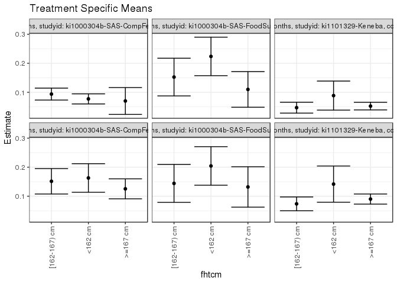

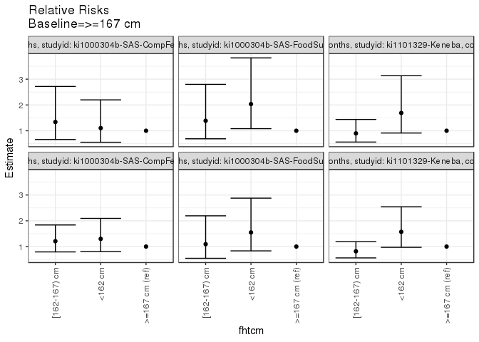

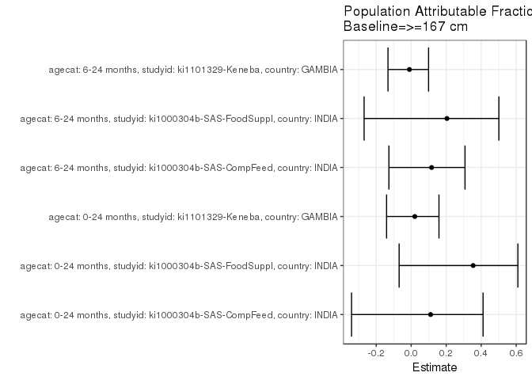

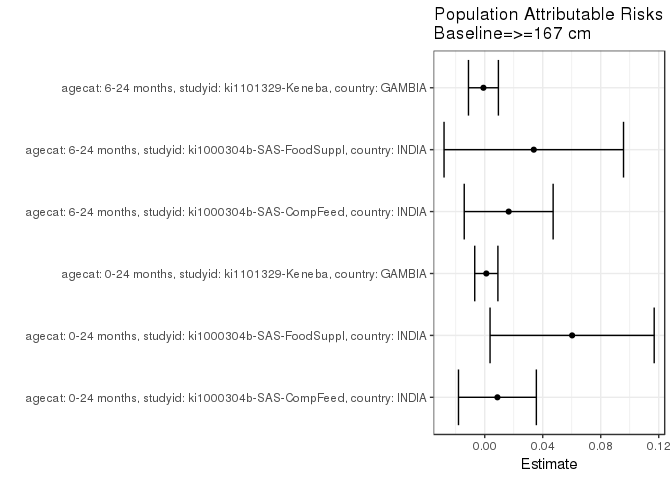

## Results Table

### Parameter: TSM

| agecat | studyid | country | intervention_level | baseline_level | estimate | ci_lower | ci_upper |
| --- | --- | --- | --- | --- | --- | --- | --- |
| 0-24 months | ki1000304b-SAS-CompFeed | INDIA | >=167 cm | NA | 0.0701299 | 0.0238669 | 0.1163929 |
| 0-24 months | ki1000304b-SAS-CompFeed | INDIA | <162 cm | NA | 0.0773196 | 0.0599210 | 0.0947181 |
| 0-24 months | ki1000304b-SAS-CompFeed | INDIA | [162-167) cm | NA | 0.0938776 | 0.0732925 | 0.1144626 |
| 0-24 months | ki1000304b-SAS-FoodSuppl | INDIA | >=167 cm | NA | 0.1100000 | 0.0485917 | 0.1714083 |
| 0-24 months | ki1000304b-SAS-FoodSuppl | INDIA | <162 cm | NA | 0.2236842 | 0.1573480 | 0.2900205 |
| 0-24 months | ki1000304b-SAS-FoodSuppl | INDIA | [162-167) cm | NA | 0.1525424 | 0.0875819 | 0.2175028 |
| 0-24 months | ki1101329-Keneba | GAMBIA | >=167 cm | NA | 0.0524887 | 0.0393359 | 0.0656415 |
| 0-24 months | ki1101329-Keneba | GAMBIA | <162 cm | NA | 0.0887097 | 0.0386512 | 0.1387682 |
| 0-24 months | ki1101329-Keneba | GAMBIA | [162-167) cm | NA | 0.0471311 | 0.0283235 | 0.0659388 |
| 6-24 months | ki1000304b-SAS-CompFeed | INDIA | >=167 cm | NA | 0.1253644 | 0.0909817 | 0.1597472 |
| 6-24 months | ki1000304b-SAS-CompFeed | INDIA | <162 cm | NA | 0.1627907 | 0.1135622 | 0.2120192 |
| 6-24 months | ki1000304b-SAS-CompFeed | INDIA | [162-167) cm | NA | 0.1513761 | 0.1075381 | 0.1952142 |
| 6-24 months | ki1000304b-SAS-FoodSuppl | INDIA | >=167 cm | NA | 0.1318681 | 0.0622500 | 0.2014863 |
| 6-24 months | ki1000304b-SAS-FoodSuppl | INDIA | <162 cm | NA | 0.2042254 | 0.1378226 | 0.2706281 |
| 6-24 months | ki1000304b-SAS-FoodSuppl | INDIA | [162-167) cm | NA | 0.1441441 | 0.0787080 | 0.2095803 |
| 6-24 months | ki1101329-Keneba | GAMBIA | >=167 cm | NA | 0.0901246 | 0.0727405 | 0.1075087 |
| 6-24 months | ki1101329-Keneba | GAMBIA | <162 cm | NA | 0.1416667 | 0.0792568 | 0.2040765 |
| 6-24 months | ki1101329-Keneba | GAMBIA | [162-167) cm | NA | 0.0735931 | 0.0497765 | 0.0974097 |

### Parameter: E(Y)

| agecat | studyid | country | intervention_level | baseline_level | estimate | ci_lower | ci_upper |
| --- | --- | --- | --- | --- | --- | --- | --- |
| 0-24 months | ki1000304b-SAS-CompFeed | INDIA | NA | NA | 0.0788835 | 0.0568416 | 0.1009254 |
| 0-24 months | ki1000304b-SAS-FoodSuppl | INDIA | NA | NA | 0.1702703 | 0.1319196 | 0.2086209 |
| 0-24 months | ki1101329-Keneba | GAMBIA | NA | NA | 0.0535818 | 0.0429272 | 0.0642365 |
| 6-24 months | ki1000304b-SAS-CompFeed | INDIA | NA | NA | 0.1418827 | 0.1234081 | 0.1603573 |
| 6-24 months | ki1000304b-SAS-FoodSuppl | INDIA | NA | NA | 0.1656977 | 0.1263498 | 0.2050455 |
| 6-24 months | ki1101329-Keneba | GAMBIA | NA | NA | 0.0892308 | 0.0753659 | 0.1030957 |

### Parameter: RR

| agecat | studyid | country | intervention_level | baseline_level | estimate | ci_lower | ci_upper |
| --- | --- | --- | --- | --- | --- | --- | --- |
| 0-24 months | ki1000304b-SAS-CompFeed | INDIA | >=167 cm | >=167 cm | 1.0000000 | 1.0000000 | 1.000000 |
| 0-24 months | ki1000304b-SAS-CompFeed | INDIA | <162 cm | >=167 cm | 1.1025200 | 0.5529835 | 2.198168 |
| 0-24 months | ki1000304b-SAS-CompFeed | INDIA | [162-167) cm | >=167 cm | 1.3386243 | 0.6595285 | 2.716964 |
| 0-24 months | ki1000304b-SAS-FoodSuppl | INDIA | >=167 cm | >=167 cm | 1.0000000 | 1.0000000 | 1.000000 |
| 0-24 months | ki1000304b-SAS-FoodSuppl | INDIA | <162 cm | >=167 cm | 2.0334928 | 1.0807070 | 3.826285 |
| 0-24 months | ki1000304b-SAS-FoodSuppl | INDIA | [162-167) cm | >=167 cm | 1.3867488 | 0.6871668 | 2.798553 |
| 0-24 months | ki1101329-Keneba | GAMBIA | >=167 cm | >=167 cm | 1.0000000 | 1.0000000 | 1.000000 |
| 0-24 months | ki1101329-Keneba | GAMBIA | <162 cm | >=167 cm | 1.6900723 | 0.9115032 | 3.133664 |
| 0-24 months | ki1101329-Keneba | GAMBIA | [162-167) cm | >=167 cm | 0.8979296 | 0.5605329 | 1.438413 |
| 6-24 months | ki1000304b-SAS-CompFeed | INDIA | >=167 cm | >=167 cm | 1.0000000 | 1.0000000 | 1.000000 |
| 6-24 months | ki1000304b-SAS-CompFeed | INDIA | <162 cm | >=167 cm | 1.2985398 | 0.8054535 | 2.093486 |
| 6-24 months | ki1000304b-SAS-CompFeed | INDIA | [162-167) cm | >=167 cm | 1.2074888 | 0.7930041 | 1.838615 |
| 6-24 months | ki1000304b-SAS-FoodSuppl | INDIA | >=167 cm | >=167 cm | 1.0000000 | 1.0000000 | 1.000000 |
| 6-24 months | ki1000304b-SAS-FoodSuppl | INDIA | <162 cm | >=167 cm | 1.5487089 | 0.8330946 | 2.879024 |
| 6-24 months | ki1000304b-SAS-FoodSuppl | INDIA | [162-167) cm | >=167 cm | 1.0930931 | 0.5448391 | 2.193037 |
| 6-24 months | ki1101329-Keneba | GAMBIA | >=167 cm | >=167 cm | 1.0000000 | 1.0000000 | 1.000000 |
| 6-24 months | ki1101329-Keneba | GAMBIA | <162 cm | >=167 cm | 1.5718972 | 0.9717717 | 2.542635 |
| 6-24 months | ki1101329-Keneba | GAMBIA | [162-167) cm | >=167 cm | 0.8165700 | 0.5602389 | 1.190182 |

### Parameter: PAR

| agecat | studyid | country | intervention_level | baseline_level | estimate | ci_lower | ci_upper |
| --- | --- | --- | --- | --- | --- | --- | --- |
| 0-24 months | ki1000304b-SAS-CompFeed | INDIA | >=167 cm | NA | 0.0087536 | -0.0180969 | 0.0356041 |
| 0-24 months | ki1000304b-SAS-FoodSuppl | INDIA | >=167 cm | NA | 0.0602703 | 0.0036718 | 0.1168687 |
| 0-24 months | ki1101329-Keneba | GAMBIA | >=167 cm | NA | 0.0010931 | -0.0068975 | 0.0090837 |
| 6-24 months | ki1000304b-SAS-CompFeed | INDIA | >=167 cm | NA | 0.0165182 | -0.0141380 | 0.0471745 |
| 6-24 months | ki1000304b-SAS-FoodSuppl | INDIA | >=167 cm | NA | 0.0338295 | -0.0280631 | 0.0957222 |
| 6-24 months | ki1101329-Keneba | GAMBIA | >=167 cm | NA | -0.0008939 | -0.0112138 | 0.0094261 |

### Parameter: PAF

| agecat | studyid | country | intervention_level | baseline_level | estimate | ci_lower | ci_upper |
| --- | --- | --- | --- | --- | --- | --- | --- |
| 0-24 months | ki1000304b-SAS-CompFeed | INDIA | >=167 cm | NA | 0.1109690 | -0.3408593 | 0.4105451 |
| 0-24 months | ki1000304b-SAS-FoodSuppl | INDIA | >=167 cm | NA | 0.3539683 | -0.0689019 | 0.6095460 |
| 0-24 months | ki1101329-Keneba | GAMBIA | >=167 cm | NA | 0.0204013 | -0.1406203 | 0.1586915 |
| 6-24 months | ki1000304b-SAS-CompFeed | INDIA | >=167 cm | NA | 0.1164218 | -0.1273425 | 0.3074772 |
| 6-24 months | ki1000304b-SAS-FoodSuppl | INDIA | >=167 cm | NA | 0.2041643 | -0.2690628 | 0.5009273 |
| 6-24 months | ki1101329-Keneba | GAMBIA | >=167 cm | NA | -0.0100175 | -0.1325446 | 0.0992537 |